# Categorizing Pitches in Baseball

## How is pitch type detected today?

There are three key features of every pitch to watch for:

1. **Velocity** - the speed of the pitch
2. **Movement** - the general movement of the pitch
3. **Break** - the shift in direction

…and by asking the pitcher what types he throws.

Source: [Baseball pitches illustrated by Lokesh Dhakar](https://lokeshdhakar.com/baseball-pitches-illustrated/)

## What types of pitches are there?

#### Fastballs

Four-seam

Two-seam

Cutter

Sinker

[figure not shown]

#### Breaking balls

Curveball

Slider

Slurve

Screwball

[figure not shown]

#### Offspeed

Changeup

Palmball

Circle change

Splitter

[figure not shown]

There’s another couple of pitches that don’t quite fall into any of those categories: eephus, knuckle, fork, gyro. Source: [Baseball pitches illustrated by Lokesh Dhakar](https://lokeshdhakar.com/baseball-pitches-illustrated/)

## How many pitch types exist?

```r
pitch.types.df <- data.all |>
  left_join(pitchtypes) |>
  mutate(pitch=factor(pitch)) |>
  group_by(pitch,category) |>
  count() |>
  arrange(desc(n))

pitch.types.df |>
ggplot(aes(x=reorder(pitch,-n),y=n)) +
  geom_bar(stat="identity",fill="#999999") +
  geom_text(aes(label=pitch,y=0),angle=90,nudge_y = 5000,hjust=0)+
  labs(x="Pitch Type",
       y="Number of Pitches") +
  scale_y_continuous(labels=scales::label_comma()) +
  ggthemes::theme_hc() +
  theme(axis.ticks.x = element_blank(),
        axis.text.x = element_blank())
```

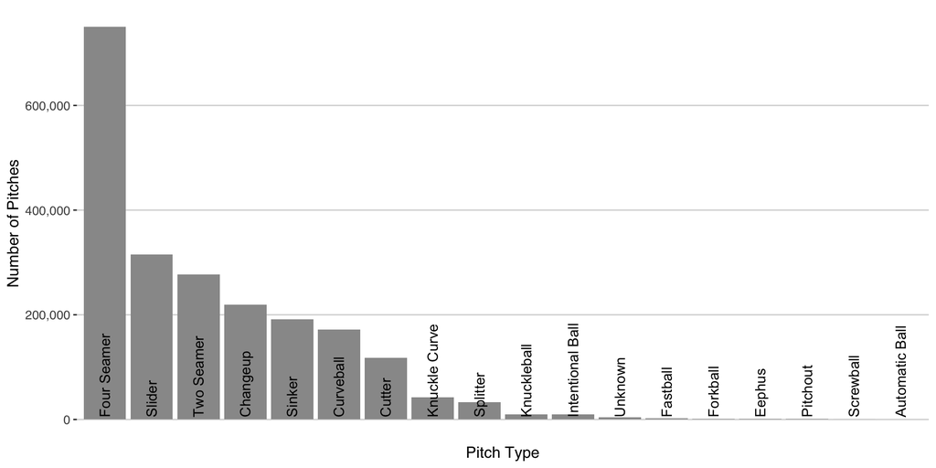

## What data do we have to work with?

Variables that I use from the dataset:

- Pitcher ID (*pitcherId*)
- Pitch type (*pitchType*, *pitch*, *category*)
- Release velocity (*releaseVelocity*)
- Velocity along the X axis of the field at the first measurement (*vx0*, *vy0*, *vz0*)
- Acceleration of the ball (*ax*, *ay*, *az*)
- Spin rate (*spinRate*)
- Spin direction (*spinDir*)
- Distance from the horizontal center of the plate as the ball crosses the front plane of the plate (*px*)
- Height above the ground as the ball crosses the front plane of the plate (*pz*)
- Distance from the center of the plate at the first measurement (*x0*, *y0*, *z0*)

## How many clusters should I use?

```r
pitch.data.cv <- vfold_cv(pitch.data, v=5)
km.stats.spec <- k_means(mode="partition",engine="stats",num_clusters=tune())
pitch.data.recipe <- recipe(~ .,
                            data = pitch.data) |>
  step_rm(pitcherId, pitchType, pitch, category)
km.workflow <- workflow(pitch.data.recipe, km.stats.spec)
cluster.grid <- grid_regular(num_clusters(range=c(4,15)),
                             levels=12)
km.results <- tune_cluster(
  km.workflow,
  resamples=pitch.data.cv,
  grid=cluster.grid,
  control=control_grid(save_pred=TRUE, extract=identity),
  metrics=cluster_metric_set(sse_within_total, sse_total, sse_ratio)
)
km.performance <- km.results |> collect_metrics()
km.performance |>
  filter(.metric=="sse_ratio") |>
  ggplot(aes(x=num_clusters, y=mean)) +
  geom_point() +
  geom_line() +
  ggthemes::theme_hc() +
  labs(x="Number of Clusters",
       y="Mean WSS/TSS ratio over 5 folds") +
  scale_x_continuous(breaks=4:15)
```

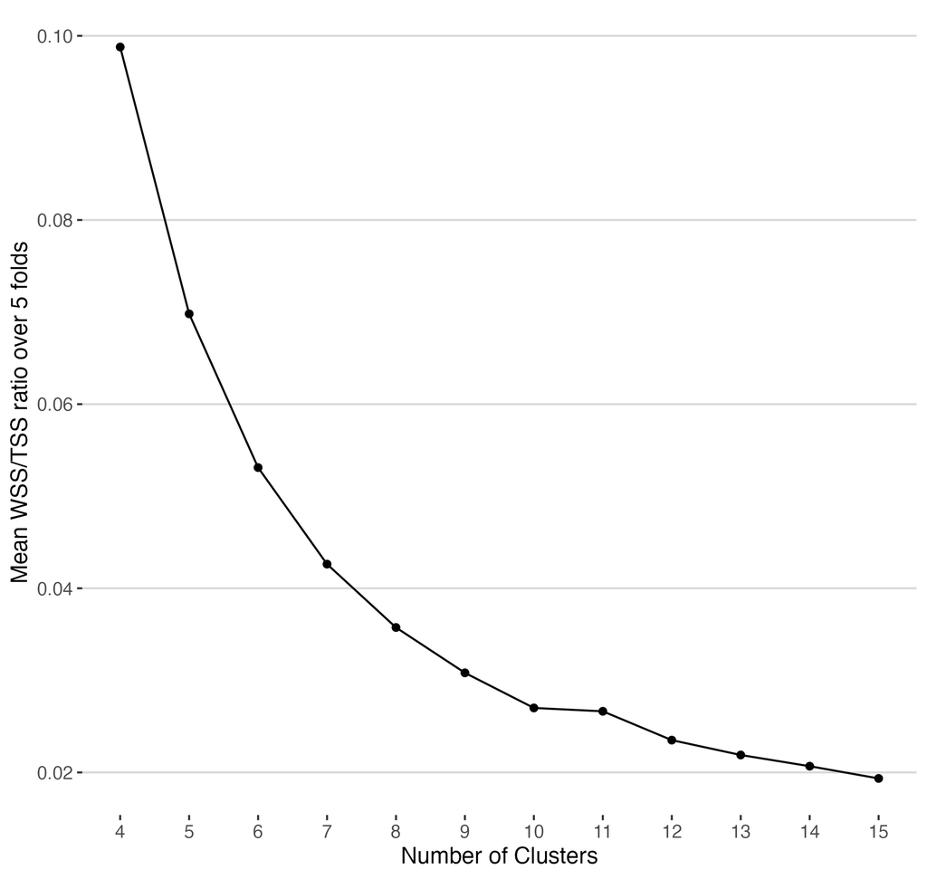

## Clustering pitches together

```r
n_clusts <- 10
km.spec.n <- k_means(mode="partition", engine="stats", num_clusters = n_clusts)

km.fit <- km.spec.n |>
  fit(~ . -pitcherId -pitchType -pitch -category, data=pitch.data)

km.fit |> tidy() |>
  select(cluster, size, releaseVelocity, spinRate, spinDir, px, pz, x0, z0, vx0, vy0, vz0, ax, ay, az) |>
  knitr::kable(digits=2,format.args = list(big.mark = ",",scientific = FALSE)) |>
  kableExtra::kable_styling(latex_options = "scale_down")
```

| cluster | size | releaseVelocity | spinRate | spinDir | px | pz | x0 | z0 | vx0 | vy0 | vz0 | ax | ay | az |
| --- | --- | --- | --- | --- | --- | --- | --- | --- | --- | --- | --- | --- | --- | --- |
| 1 | 253,185 | 90.56 | 2,156.25 | 189.05 | -0.07 | 2.41 | -0.70 | 5.87 | 2.35 | -132.52 | -5.38 | -3.85 | 28.81 | -18.65 |
| 2 | 250,592 | 89.57 | 1,981.08 | 190.69 | -0.13 | 2.41 | -0.90 | 5.86 | 2.80 | -131.10 | -4.75 | -4.36 | 28.00 | -21.01 |
| 3 | 235,132 | 84.37 | 1,263.99 | 157.67 | -0.04 | 2.19 | -0.99 | 5.92 | 2.12 | -123.57 | -3.16 | 0.87 | 24.32 | -28.40 |
| 4 | 239,909 | 83.56 | 865.60 | 161.01 | 0.02 | 2.05 | -0.76 | 5.92 | 1.71 | -122.38 | -3.09 | 1.29 | 23.55 | -30.08 |
| 5 | 70,505 | 92.46 | 2,933.46 | 166.03 | 0.09 | 2.31 | 0.53 | 5.86 | -2.16 | -135.13 | -7.12 | 5.36 | 31.59 | -12.25 |
| 6 | 259,554 | 86.12 | 1,569.13 | 194.63 | -0.18 | 2.29 | -0.95 | 5.87 | 2.62 | -126.11 | -3.43 | -3.37 | 25.66 | -26.43 |
| 7 | 223,821 | 91.44 | 2,336.79 | 190.16 | -0.01 | 2.39 | -0.61 | 5.88 | 2.35 | -133.76 | -6.03 | -4.10 | 29.62 | -16.41 |
| 8 | 227,071 | 88.11 | 1,801.24 | 190.41 | -0.17 | 2.36 | -1.04 | 5.85 | 3.02 | -129.00 | -4.05 | -4.27 | 27.02 | -23.77 |
| 9 | 208,841 | 91.77 | 2,563.43 | 174.45 | 0.06 | 2.36 | 0.10 | 5.88 | -0.33 | -134.20 | -6.51 | 1.27 | 30.24 | -14.62 |
| 10 | 175,253 | 83.34 | 430.82 | 157.31 | 0.05 | 1.93 | -0.61 | 5.91 | 1.48 | -122.04 | -3.09 | 0.89 | 23.57 | -31.27 |

## How did the model perform?

```r
dists |>
  group_by(category, pitchType,.cluster_pred) |>
  count() |>
  ggplot(aes(x=pitchType,
             y=.cluster_pred,
             fill=.cluster_pred,
             alpha=n,
             label=scales::label_number(accuracy=1,scale_cut = cut_short_scale())(n),
             group=category)) +
  geom_tile() +
  geom_text(aes(color=ifelse(n<15000,"white","black"))) +
  labs(x="Pitch Type",
       y="") +
  scale_fill_discrete(type="viridis") +
  scale_x_discrete(limits=rev) +
  scale_color_identity() +
  facet_grid(category~., scales="free", switch="y", space="free_y") +
  coord_flip() +
  guides(fill="none",alpha="none") +
  ggthemes::theme_hc() +
  theme(strip.placement="outside",
        strip.background = element_blank(),
        panel.grid.major.y = element_blank())
```

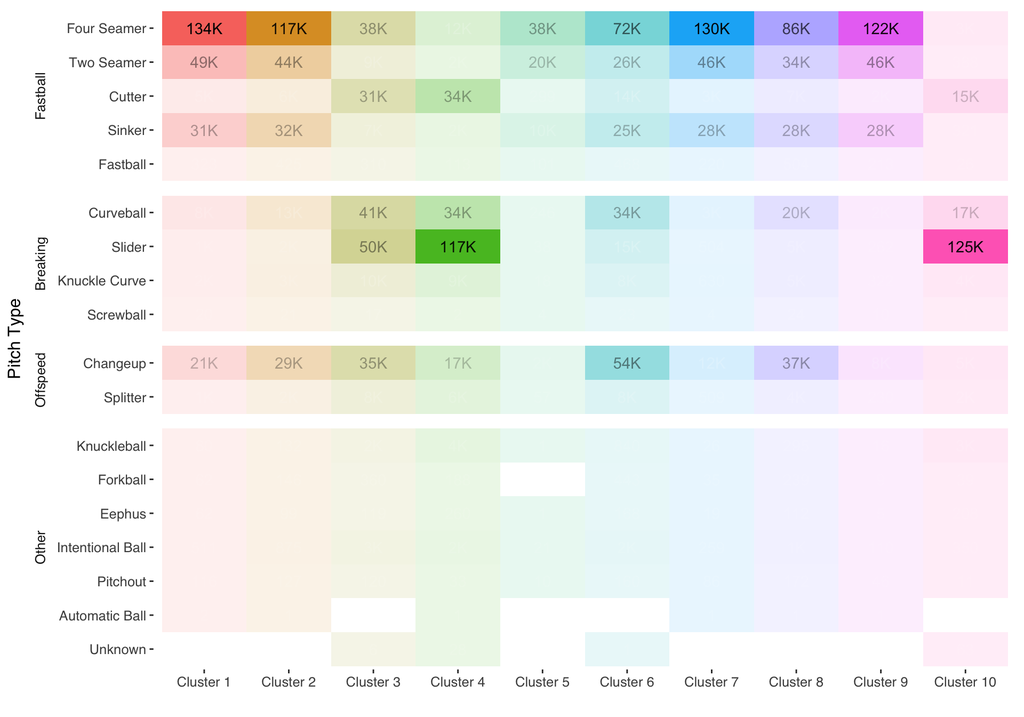

## What about those pitches that don’t really fit?

```r
outliers <- dists |>
  group_by(.cluster_pred) |>
  mutate(outlier = ifelse(dist_from_centroid > quantile(dist_from_centroid, 0.75)+1.5*IQR(dist_from_centroid),"#DC3220","#212529")) |>
  mutate(outlier = ifelse(dist_from_centroid < quantile(dist_from_centroid, 0.25)-1.5*IQR(dist_from_centroid),"#DC3220",outlier))

outliers |>
  ggplot(aes(x=.cluster_pred,y=dist_from_centroid)) +
  geom_boxplot(outlier.shape=NA) +
  geom_jitter(data=outliers |> filter(outlier=="#DC3220"), aes(color=outlier), width=.15, alpha=.1) +
  labs(y="Distance from Centroid",
       x="") +
  scale_color_identity() +
  guides(color="none") +
  ggthemes::theme_hc()
```

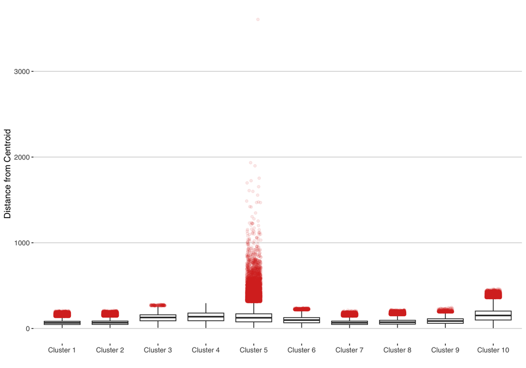

## What do those outliers look like?

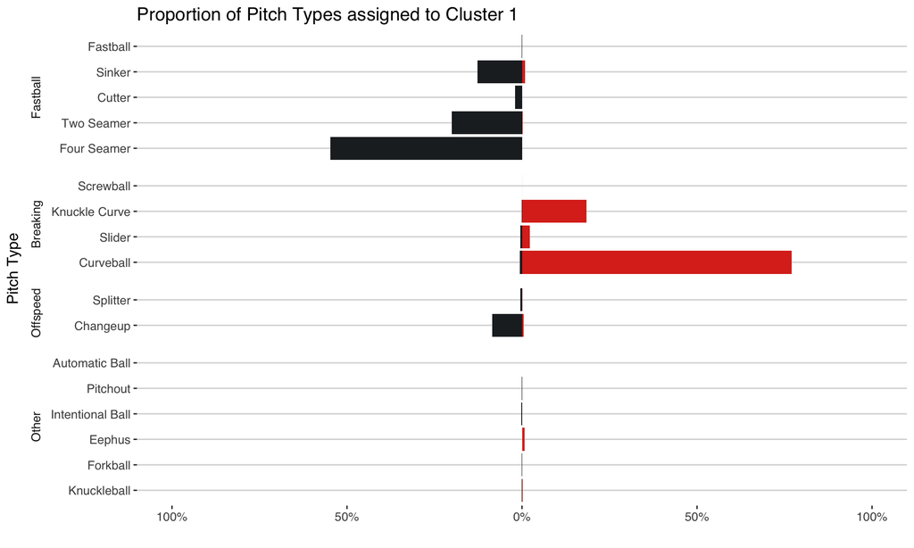

```r
outliers |>
  filter(.cluster_pred=="Cluster 1") |>
  group_by(category,pitchType,outlier) |>
  count() |> group_by(outlier) |>
  mutate(pct=n/sum(n),
         pct=ifelse(outlier=="#212529",-1*pct,pct)) |>
  ggplot(aes(x=pitchType,y=pct,fill=outlier)) +
  geom_col() +
  facet_grid(category~., scales="free", switch="y", space="free_y") +
  scale_y_continuous(breaks = c(-1,-.5,0,.5,1),
                     limits = c(-1,1),
                     labels=c("100%","50%","0%","50%","100%")) +
  scale_fill_identity() +
  coord_flip() +
  labs(x="Pitch Type",
       y="",
       title="Proportion of Pitch Types assigned to Cluster 1") +
  ggthemes::theme_hc() +
  theme(strip.placement="outside",
        strip.background = element_blank())
```

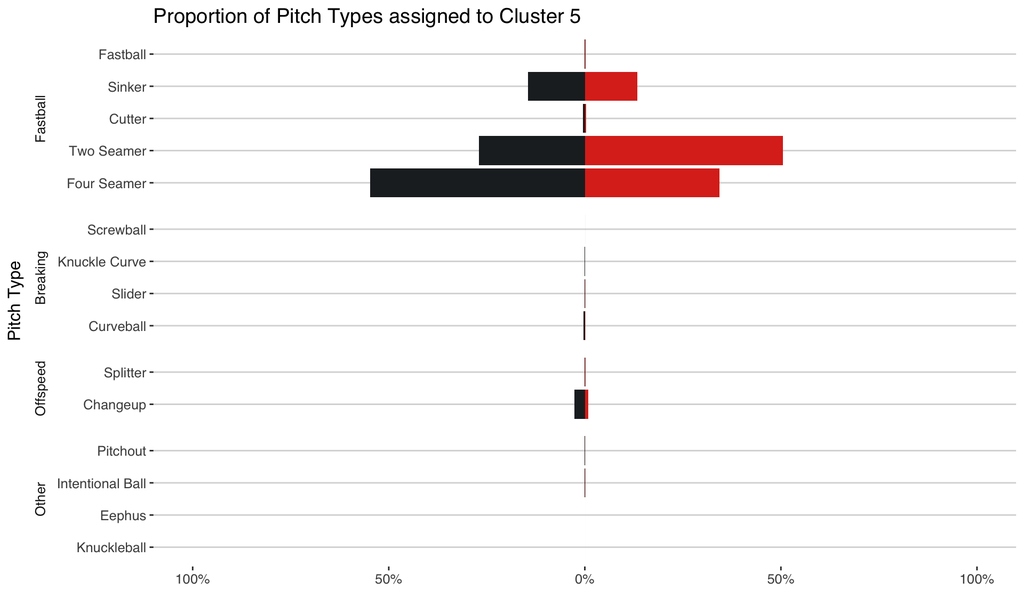

```r
outliers |>
  filter(.cluster_pred=="Cluster 5") |>
  group_by(category,pitchType,outlier) |>
  count() |> group_by(outlier) |>
  mutate(pct=n/sum(n),
         pct=ifelse(outlier=="#212529",-1*pct,pct)) |>
  ggplot(aes(x=pitchType,y=pct,fill=outlier)) +
  geom_col() +
  facet_grid(category~., scales="free", switch="y", space="free_y") +
  scale_y_continuous(breaks = c(-1,-.5,0,.5,1),
                     limits = c(-1,1),
                     labels=c("100%","50%","0%","50%","100%")) +
  scale_fill_identity() +
  coord_flip() +
  labs(x="Pitch Type",
       y="",
       title="Proportion of Pitch Types assigned to Cluster 5") +
  ggthemes::theme_hc() +
  theme(strip.placement="outside",
        strip.background = element_blank())
```

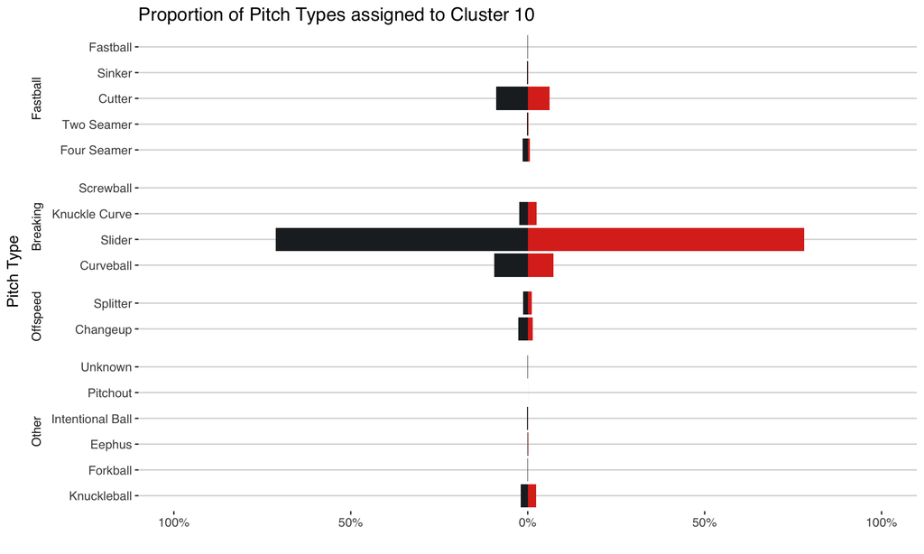

```r
outliers |>
  filter(.cluster_pred=="Cluster 10") |>
  group_by(category,pitchType,outlier) |>
  count() |> group_by(outlier) |>
  mutate(pct=n/sum(n),
         pct=ifelse(outlier=="#212529",-1*pct,pct)) |>
  ggplot(aes(x=pitchType,y=pct,fill=outlier)) +
  geom_col() +
  facet_grid(category~., scales="free", switch="y", space="free_y") +
  scale_y_continuous(breaks = c(-1,-.5,0,.5,1),
                     limits = c(-1,1),
                     labels=c("100%","50%","0%","50%","100%")) +
  scale_fill_identity() +
  coord_flip() +
  labs(x="Pitch Type",
       y="",
       title="Proportion of Pitch Types assigned to Cluster 10") +
  ggthemes::theme_hc() +
  theme(strip.placement="outside",
        strip.background = element_blank())
```

## Thank you

### Christopher Teixeira

christopherteixeira.com

chris@christopherteixeira.com

[in/christopherteixeira](https://www.linkedin.com/in/christopherteixeira/)

christopher-teixeira

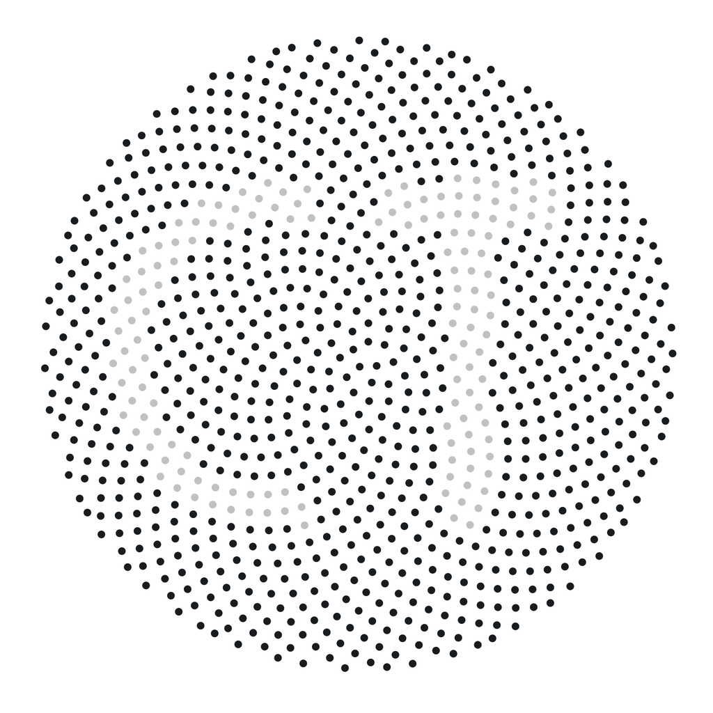

Christopher Teixeira